# Grupowanie dokumentów

Bogna Zacny

zima 2019/2020

## Przygotowanie środowiska

Przydatne pakiety

```
install.packages(c("tm", "dendextend", "ggplot2", "dplyr", "proxy", "tm", "stringr"))

library("proxy")
library("ggplot2")
library("dendextend")
library("dplyr")
library("tm")
library("stringr")
```

Przestrzeń robocza

```
setwd("C:/Users/UE/Documents/R")
```

## Grupowanie dokumentów

### Przygotowanie zbioru dokumentów

W przykładzie korpus składa się z “dokumentów”, będących zdaniami - przysłowiami polskimi.

```r
przyslowia <- scan("przyslowia.txt", encoding = "UTF-8", what="character", sep=",")

przyslowia_czyste <- removePunctuation(przyslowia)
przyslowia_czyste <- str_replace(przyslowia_czyste, "–", "")

przyslowia_czyste <- tolower(przyslowia_czyste)

stopSlowa <- c("czego", "czy", "i", "tego", "w", "z")
przyslowia_czyste <- removeWords(przyslowia_czyste, stopSlowa)

przyslowia_czyste <- stripWhitespace(przyslowia_czyste)
przyslowia_czyste <- str_trim(przyslowia_czyste)
```

Lematyzacja z uproszczonym słownikiem słów

```r
slownikMaly <- read.csv2("slownik.txt", header=F, stringsAsFactors=FALSE)
podstawaMaly<-slownikMaly[,1]
names(podstawaMaly)<-slownikMaly[,2]
przyslowia_lemmy <- str_replace_all(przyslowia_czyste, podstawaMaly)
```

Utworzenie macierzy **dokument-term** z wagami liczebnościowymi:

```r
przyslowia_zrodlo <- VectorSource(przyslowia_lemmy)
przyslowia_korp <- VCorpus(przyslowia_zrodlo)

przyslowia_dtm <- DocumentTermMatrix(przyslowia_korp)
```

### Grupowanie hierarchiczne

Zbiór danych wejściowy grupowania hierarchicznego to macierz odległości pomiędzy grupowanymi obiektami. Obliczenie odległości pomiędzy dokumentami:

```r
przyslowia_dm <- as.matrix(przyslowia_dtm)
odl <- dist(przyslowia_dm)
```

W funkcji `dist()` domyślną miarą odległości jest miara euklidesowa (`method = "euclidean"`).

Do wykonania grupowania hierarchicznego można użyć funkcji `hclust()`:

```r
hg <- hclust(odl)
```

Domyślą odległością pomiędzy skupieniami jest **metoda całkowitego połaczenia** (`method = "complete"`). Odległość pomiędzy skupieniami zdefiniowana jest jako odległość miedzy dwoma najbardziej oddalonymi punktami, po jednym z każdej grupy. Poszukiwana jest minimalna odległość pomiędzy dowolnymi rekordami z dwóch grup, które są najbardziej oddalone od siebie.

> Gdy chcemy zmienić domyślne ustawienia funkcji `dist()` i `hclus()` należy zmodyfikować argument `method` podając nazwę wybranej metody obliczania odległości.

Wyświetlenie dendrogramu:

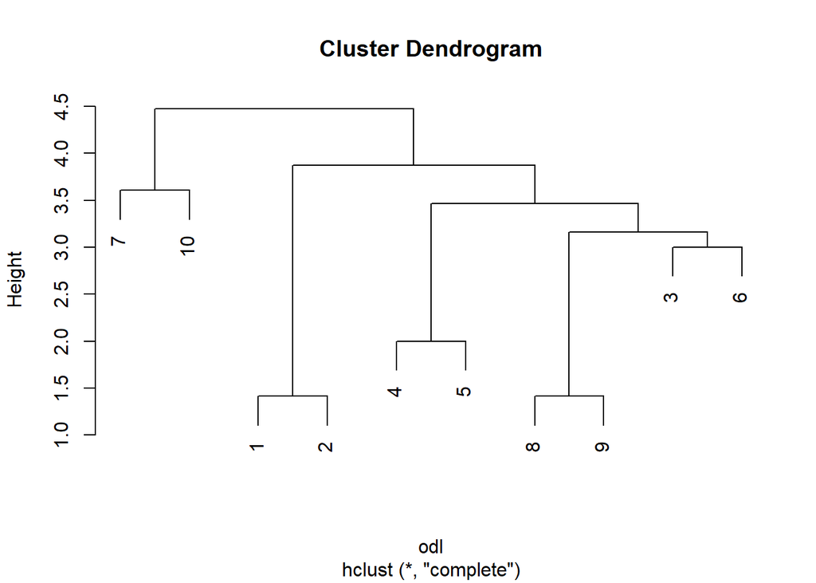

```r
plot(hg)
```

#### Poprawienie wyglądu dendrogramu

Aby przygotować ładniejszy dendrogram można wykorzystać bibliotekę **`dendextend`**

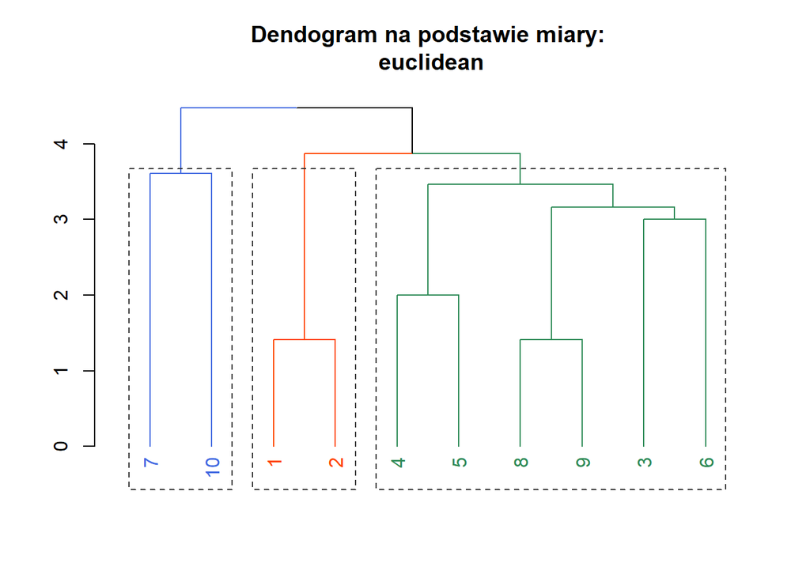

```r
hg_ladne <- as.dendrogram(hg)

# zmiana atrybutów etykiet obiektów i gałęzi należących do skupień
hg_ladne <- color_labels(hg_ladne,3, col = c("royalblue", "orangered", "seagreen"))
hg_ladne <- color_branches(hg_ladne,3, col = c("royalblue", "orangered", "seagreen"))

# rysowanie dendogramu
plot(hg_ladne, main = paste("Dendogram na podstawie miary:\n", "euclidean"))
rect.dendrogram(hg_ladne, k = 3, border = "grey20", lty = 2)
```

#### Zadanie domowe.

1. Przygotuj funkcję, która stworzy dendrogram dla podanej macierzy dokument-term i wskazanej miary odległości. Jako miarę odległości pomiędzy skupieniami należy wybrać `method = "ward.D"` (metoda ta wykorzystuje podejścia **analizy wariancji** do oszacowania odległości między skupieniami).

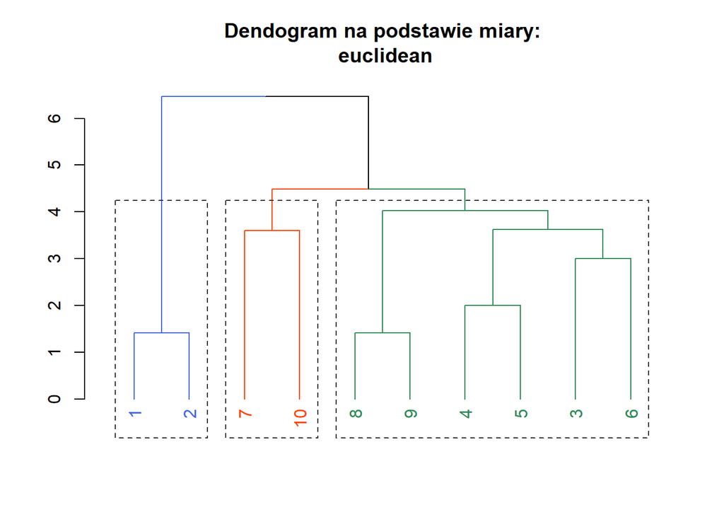

```r
rys_dend(przyslowia_dm, "euclidean")
```

2. Przygotuj wykres porównujący wyniki grupowania dokumentów przy zastosowaniu wybranych miar odległości

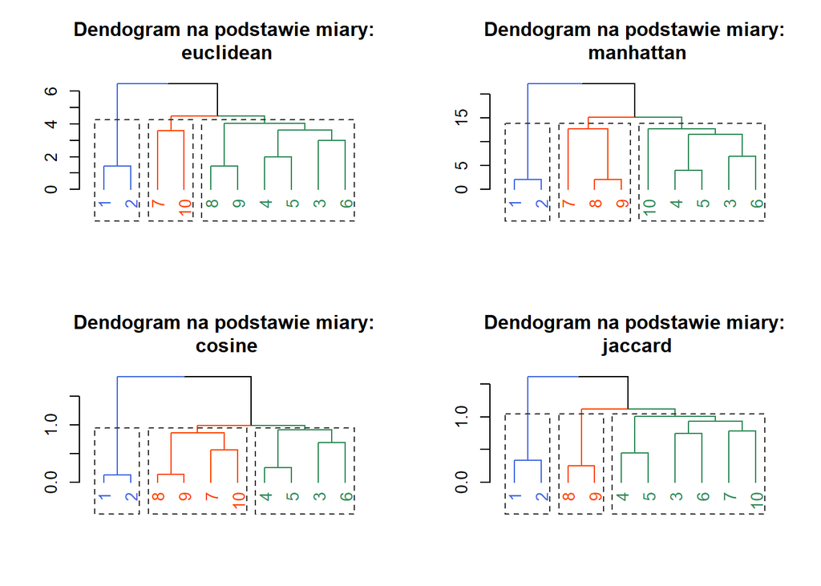

## Grupowanie niehierarchiczne

Zbiór danych wejściowy grupowania niehierarchicznego to macierz dokument-term a nie macierz odległości. W trakcie poszukiwania najbardziej optymalnego przydziału obiektów do grup, podczas każdej iteracji dokonuje się porównywania odległości obiektów od tymczasowych centrów grup. W metodzie *k-means* miarą odległości jest miara euklidesowa. Miara ta jest bardzo wrażliwa na punkty oddalone, co w text mining oznacza silny wpływ na wyniki dokumentów o dużej liczbie termów lub termów często występujących w dokumentach. Aby uniknąć tego problemu należy znormalizować wektory reprezentujące dokumenty w przestrzeni termów. Normalizacja wektora sprowadza się do wyznaczenia wektora jednostkowego $\mathbf{\hat{a}}$

$$\mathbf{\hat{a}} = \frac{\mathbf{a}}{\left \| \mathbf{a} \right \|}$$

gdzie:

$\left \| \mathbf{a} \right \|$ - to długość wektora $\mathbf{a}$ obliczana według wzoru:

$${\left \| \mathbf{a} \right \|} = \sqrt{\sum_{i=1}^{n}(a_{i})^{2}}$$

#### Zadanie 1.

Poniższa tabela przedstawia **macierz dokument-term** dla trzech dokumentów i dwóch termów, znormalizuj wektory reprezentujące dokumenty.

```
##      dobry zły
## doc1     1   3
## doc2     3   9
## doc3     3   1
```

```
##          dobry       zły
## doc1 0.3162278 0.9486833
## doc2 0.3162278 0.9486833
## doc3 0.9486833 0.3162278
```

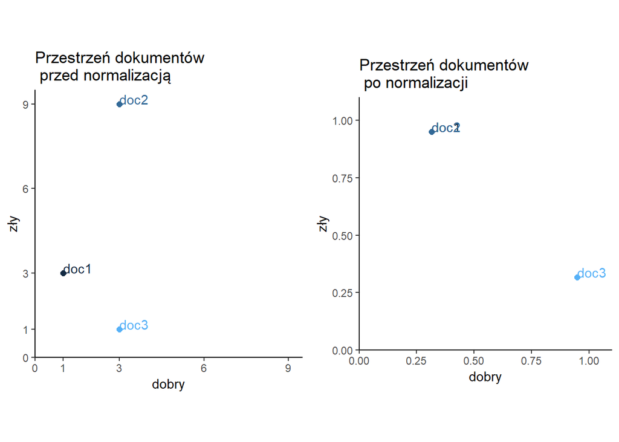

Normalizacja wszystkich wektorów reprezentujących dokumenty, czyli normalizacja wierszy macierzy dokument-term:

```r
przyslowia_scale <- t(scale(t(przyslowia_dm),
                            center=FALSE,
                            scale=sqrt(rowSums(przyslowia_dm^2))))

# alternatywna metoda
# przyslowia_scale <- przyslowia_dm/apply(przyslowia_dm, MARGIN=1, FUN=function(x) sum(x^2)^.5)
```

```r
# grupowanie k-means
km <- kmeans(przyslowia_scale, 3)
km
```

```
## K-means clustering with 3 clusters of sizes 6, 2, 2
##
## Cluster means:
##   bartłomiej        bez       być      cały        dać   dostatek
## 1  0.3544437 0.05025189 0.1259882 0.0000000 0.05025189 0.05555556
## 2  0.0000000 0.00000000 0.0000000 0.0000000 0.00000000 0.00000000
## 3  0.3931064 0.00000000 0.0000000 0.2041241 0.00000000 0.00000000
##        dożyć   dzień      jaki    jesień        lat     marcin następować
## 1 0.05555556 0.17624 0.4025562 0.3063312 0.05555556 0.04811252  0.1300912
## 2 0.00000000 0.00000 0.0000000 0.3535534 0.00000000 0.00000000  0.0000000
## 3 0.00000000 0.00000 0.0000000 0.3931064 0.00000000 0.00000000  0.0000000
##   naśladować       nie     nieść       nim     ochyby   pogodny       pora
## 1  0.0000000 0.0000000 0.1259882 0.0000000 0.05025189 0.0000000 0.05025189
## 2  0.0000000 0.7071068 0.0000000 0.0000000 0.00000000 0.0000000 0.00000000
## 3  0.2041241 0.0000000 0.0000000 0.2041241 0.00000000 0.3779645 0.00000000
##     przyszły    święty świętyięty      taki      takić      takiż
## 1 0.05555556 0.0000000 0.05025189 0.1464769 0.06299408 0.06299408
## 2 0.00000000 0.0000000 0.00000000 0.0000000 0.00000000 0.00000000
## 3 0.00000000 0.1889822 0.00000000 0.0000000 0.00000000 0.00000000
##     urodzić    wiosna   wrzesień    zasiać       zima     zostać   zrodzić
## 1 0.0000000 0.0000000 0.04811252 0.0000000 0.04811252 0.05025189 0.0000000
## 2 0.1767767 0.3535534 0.00000000 0.3535534 0.00000000 0.00000000 0.1767767
## 3 0.0000000 0.0000000 0.20412415 0.0000000 0.00000000 0.00000000 0.0000000
##   zwiastować
## 1  0.1300912
## 2  0.0000000
## 3  0.0000000
##
## Clustering vector:
##  1  2  3  4  5  6  7  8  9 10
##  2  2  3  1  1  3  1  1  1  1
##
## Within cluster sum of squares by cluster:
## [1] 2.7479500 0.1250000 0.6913933
##  (between_SS / total_SS =  44.3 %)
##
## Available components:
##
## [1] "cluster"      "centers"      "totss"        "withinss"
## [5] "tot.withinss" "betweenss"    "size"         "iter"
## [9] "ifault"
```

```r
sort(km$centers[1,], decreasing = T)
```

```
##       jaki bartłomiej     jesień      dzień       taki następować
## 0.40255625 0.35444373 0.30633120 0.17624005 0.14647694 0.13009115
## zwiastować        być      nieść      takić      takiż   dostatek
## 0.13009115 0.12598816 0.12598816 0.06299408 0.06299408 0.05555556
##      dożyć        lat   przyszły        bez        dać     ochyby
## 0.05555556 0.05555556 0.05555556 0.05025189 0.05025189 0.05025189
##       pora świętyięty     zostać     marcin   wrzesień       zima
## 0.05025189 0.05025189 0.05025189 0.04811252 0.04811252 0.04811252
##       cały naśladować        nie        nim    pogodny     święty
## 0.00000000 0.00000000 0.00000000 0.00000000 0.00000000 0.00000000
##    urodzić     wiosna     zasiać    zrodzić
## 0.00000000 0.00000000 0.00000000 0.00000000
```

```r
sort(km$centers[2,], decreasing = T)
```

```
##        nie     jesień     wiosna     zasiać    urodzić    zrodzić
##  0.7071068  0.3535534  0.3535534  0.3535534  0.1767767  0.1767767
## bartłomiej        bez        być       cały        dać   dostatek
##  0.0000000  0.0000000  0.0000000  0.0000000  0.0000000  0.0000000
##      dożyć      dzień       jaki        lat     marcin następować
##  0.0000000  0.0000000  0.0000000  0.0000000  0.0000000  0.0000000
## naśladować      nieść        nim     ochyby    pogodny       pora
##  0.0000000  0.0000000  0.0000000  0.0000000  0.0000000  0.0000000
##   przyszły     święty świętyięty       taki      takić      takiż
##  0.0000000  0.0000000  0.0000000  0.0000000  0.0000000  0.0000000
##   wrzesień       zima     zostać zwiastować
##  0.0000000  0.0000000  0.0000000  0.0000000
```

```r
colnames(km$centers)[km$centers[1,] != 0]
```

```
##  [1] "bartłomiej" "bez"        "być"        "dać"        "dostatek"
##  [6] "dożyć"      "dzień"      "jaki"       "jesień"     "lat"
## [11] "marcin"     "następować" "nieść"      "ochyby"     "pora"
## [16] "przyszły"   "świętyięty" "taki"       "takić"      "takiż"
## [21] "wrzesień"   "zima"       "zostać"     "zwiastować"
```

```r
colnames(km$centers)[km$centers[2,] != 0]
```

```
## [1] "jesień"  "nie"     "urodzić" "wiosna"  "zasiać"  "zrodzić"
```

```r
km$cluster == 1
```

```
##     1     2     3     4     5     6     7     8     9    10
## FALSE FALSE FALSE  TRUE  TRUE FALSE  TRUE  TRUE  TRUE  TRUE
```

```r
Docs(przyslowia_dtm[km$cluster == 1,])
```

```
## [1] "4"  "5"  "7"  "8"  "9"  "10"
```

```r
findFreqTerms(przyslowia_dtm[km$cluster == 1,], 2)
```

```
## [1] "bartłomiej" "być"        "dzień"      "jaki"       "jesień"
## [6] "następować" "nieść"      "taki"       "zwiastować"
```

```r
findFreqTerms(przyslowia_dtm[km$cluster == 2,], 2)
```

```
## [1] "jesień" "nie"    "wiosna" "zasiać"
```

#### Zadanie 2.

```r
info_klaster(km, 3)
```

```
## Klaster 3 tworzą dokuemnty: 3 6 . Najczęstsze termy w tych dokumentach to: bartłomiej jesień pogodny
```